# Physics Validation of Y3 Clusters Code

## 3.4 Scaling Relations

### 3.4.1 Mass-observable relation

$P(\lambda |M_{200m})$ describes the probabilistic distribution of the cluster observable richness ($\lambda$) at a given mass $M_200m$. Our calculation is implemented in the file `mor_t2.hh`.

For this testing, we compare results from our implementation to the independent function evaluations from Matteo Costanzi in the SDSS cluster cosmology analysis (Costanzi et al. 2019)

1. The comparisons are made at 51 unique $\lambda$ values with 6 different mass values.
2. Over the range tested ($1 < \lambda < 101$), the maximum magnitude of the absolute residual between the expected value and our calculated value is $1.8422198\times 10^{-8}$; the maximum magnitude of the fractional residual is $1.995633\times 10^{-5}$.
3. For this test, we require the relative differences to be less than $5\times 10^{-6}$, or the absolute difference to be less than $10^{-12}$.
4. **For this test, 306 of 306 points pass.**

Each panel in the figure below corresponds to a different $\mathrm{log} M_{200m}$ value, specified in the panel top label.

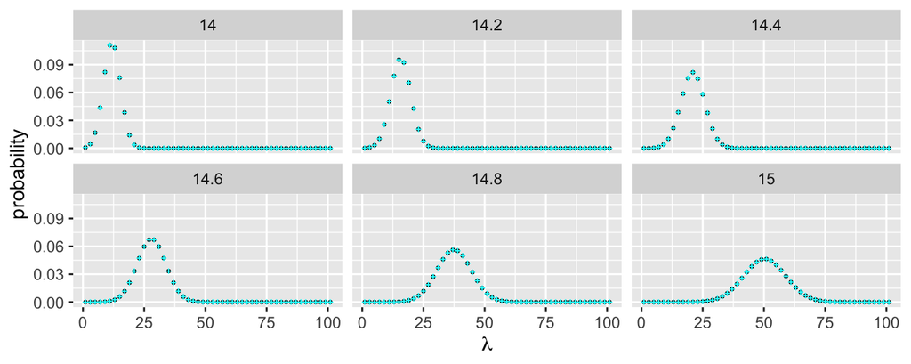

Absolute comparison of our implementation to the expected results. Note that over-plotting may obscure the expected values, if the approximated values are very close.

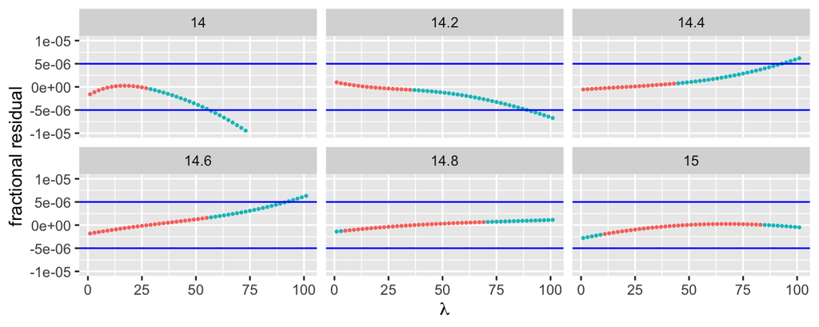

Relative residual comparison of our implementation to the expected results. Blue points pass, and red points fail, the absolute residual test.

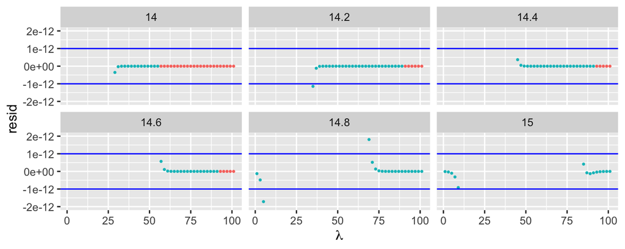

Absolute residual comparison of our approximation to the expected results for MOR. Blue points pass, and red points fail, the relative residual test.

### 3.4.2 Projection effect on Scaling relations

Projections of LOS structures cause a shift and an extra scatter to the values of cluster richness $\lambda$. $P(\lambda_c |\lambda_t)$ describes the probabilistic distribution of the richness scatter (between $\lambda_c$ and $\lambda_t$) caused by projections. Our calculation is implemented in the file `lc_lt_t.hh`.

For this testing, we compare results from our implementation to the independent function evaluations from Matteo Costanzi’s projection analyses (Costanzi et al. 2019)

1. The comparisons are made at 10 unique $\lambda_{c}$ values with 10 different $\lambda_{t}$ values.
2. Over the range tested ($2 < \lambda_{cen} < 150$), the maximum magnitude of the absolute residual between the expected value and our calculated value is $4.8340654\times 10^{-10}$; the maximum magnitude of the fractional residual is $1.466778\times 10^{-6}$.
3. For this test, we require the relative differences to be less than $10^{-6}$, or the absolute difference to be less than $10^{-12}$.
4. **For this test, 1001 of 1001 points pass.**

Each panel in the figure below corresponds to a $\lambda_{t}$ value, specified in the panel top label.

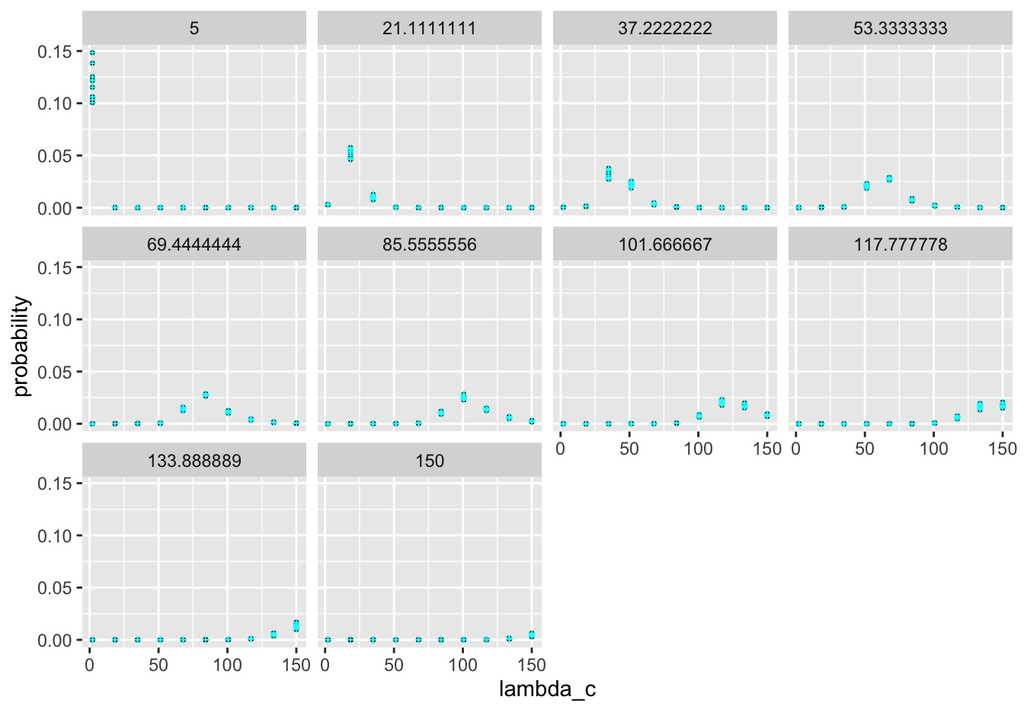

Absolute comparison of our implementation to the expected results. Note that over-plotting may obscure the expected values, if the approximated values are very close.

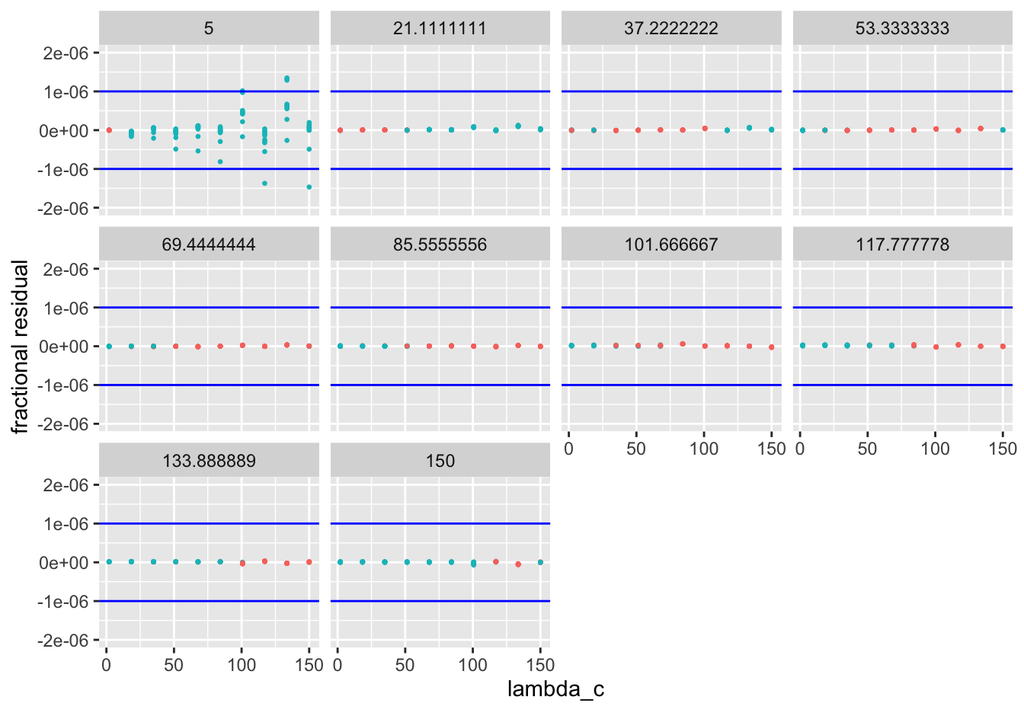

Relative residual comparison of our implementation to the expected results. Blue points pass, and red points fail, the absolute residual test.

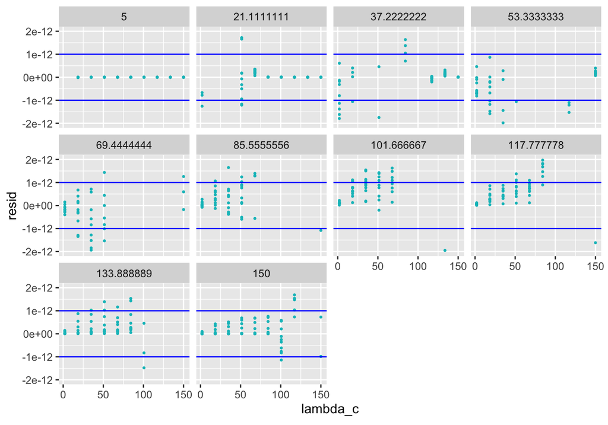

Absolute residual comparison of our implementation to the expected results. Blue points pass, and red points fail, the relative residual test.

### 3.4.3 Mis-centering effect on scaling relations

Mis-centering cause a shift and an extra scatter to the values of cluster richness $\lambda$. $P(\lambda_o/\lambda_c | R_{mis})$ describes the probabilistic distribution of the richness shift ($\lambda_o/\lambda_c$) with a mis-centering distance $R_{mis}$ Our calculation is implemented in the file `lo_lc_t.hh`.

For this testing, we compare results from our implementation to the independent function evaluations from Yuanyuan Zhang’s mis-centering analysis (Zhang et al. 2019).

1. The comparisons are made at 2092 unique values of $\lambda_{o}/\lambda_{c}$ with 20 different $R_{mis}$ values.
2. Over the range tested ($0.1 < \lambda_{cen} < 2.6457143$), the maximum magnitude of the absolute residual between the expected value and our calculated value is $8.8817842\times 10^{-15}$; the maximum magnitude of the fractional residual is $9.2157402\times 10^{-14}$.
3. For this test, we require the relative differences to be less than $10^{-6}$, or the absolute difference to be less than $10^{-12}$.
4. **For this test, 38542 of 38542 points pass.**

Each panel in the figure below corresponds to a $R_{mis}$ value, specified in the panel top label.

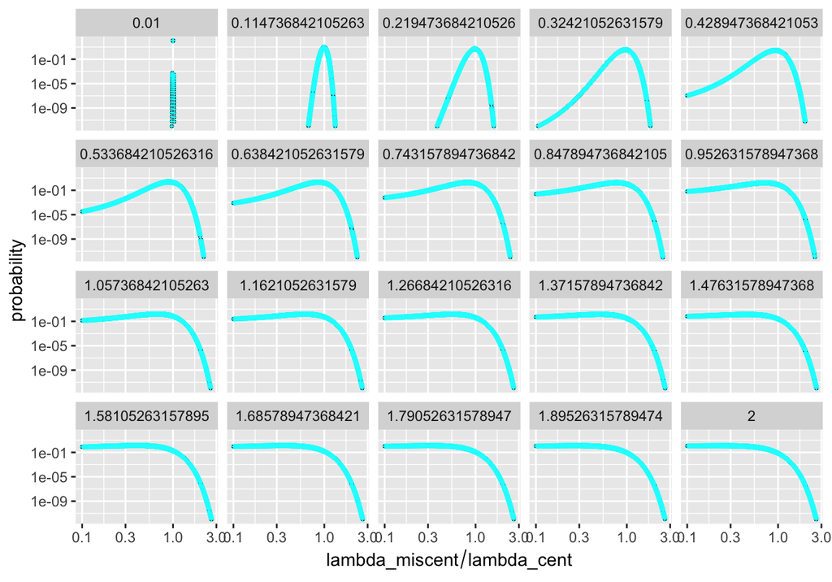

Absolute comparison of our implementation to the expected results. Note that over-plotting may obscure the expected values, if the approximated values are very close.

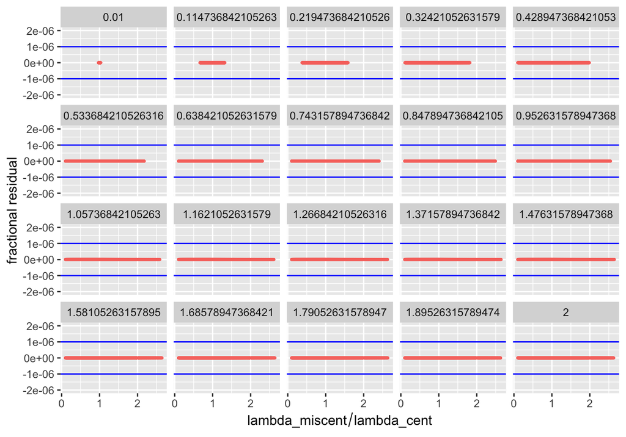

Relative residual comparison of our implementation to the expected results. Blue points pass, and red points fail, the absolute residual test.

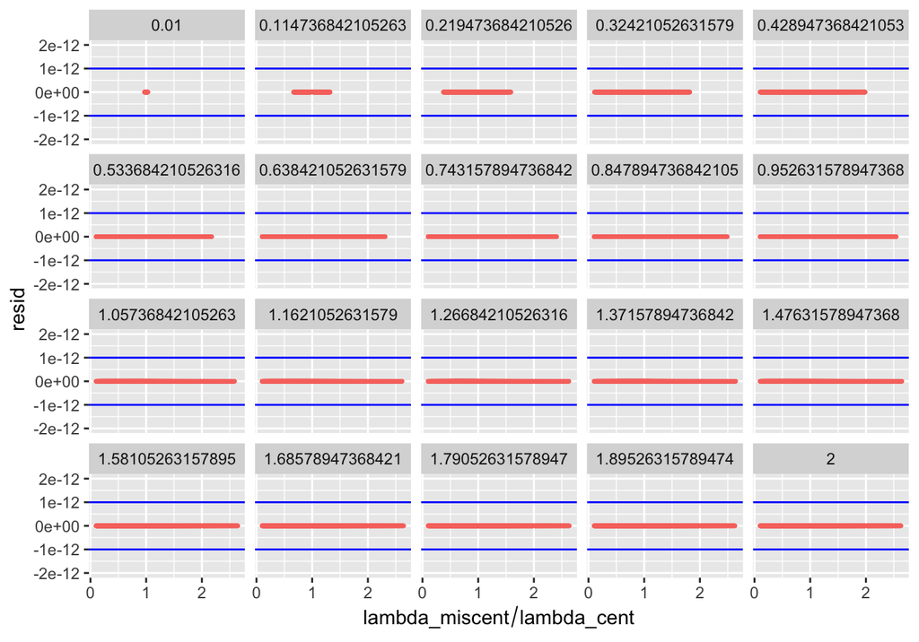

Absolute residual comparison of our implementation to the expected results. Blue points pass, and red points fail, the relative residual test.

## 3.5 Number Counts and Masses in SDSS

**This test requires running sdss_analysis.ini in cosmosis_tests first**.

In this section, we compare the stacked number counts and mass predictions in stacked richness/mass bins for a SDSS like analysis. These values are the integrated results using components listed above. For this testing, we compare results from our implementation to the implementations from Matteo Costanzi for the SDSS cosmology analysis (Costanzi et al. 2019). The test is conducted for the following set of cosmology and scaling relation parameters specified in **cosmosis_tests/values_comp.ini**.

1. The comparisons are made at 5 unique values of $\lambda$ bins.
2. Over the **number of bins** tested and for the stacked **number counts**, the maximum magnitude of the absolute residual between the expected value and our calculated value is $969.33075$; the maximum magnitude of the fractional residual is $0.2852853$.
3. Over the **number of bins** tested and for the stacked **average masses**, the maximum magnitude of the absolute residual between the expected value and our calculated value is $0.059222$; the maximum magnitude of the fractional residual is $0.0039664$.

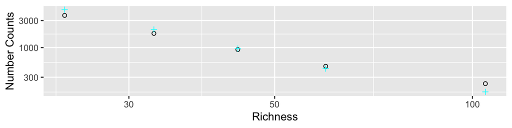

Absolute comparison of our implementation to the expected results. Note that over-plotting may obscure the expected values, if the approximated values are very close.

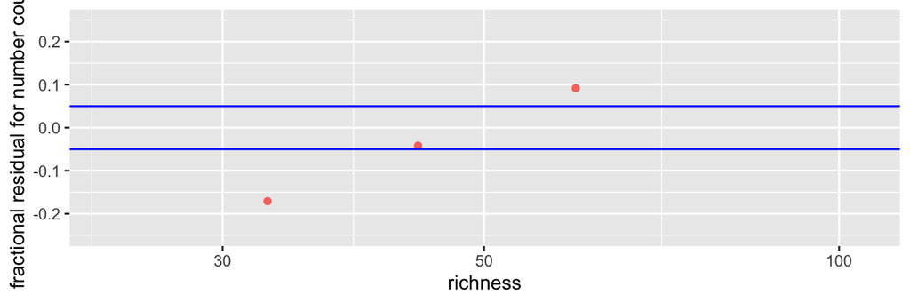

Relative residual implementation or our approximation to the expected results. Points in blue pass, and points in red fail, the absolute residual test.

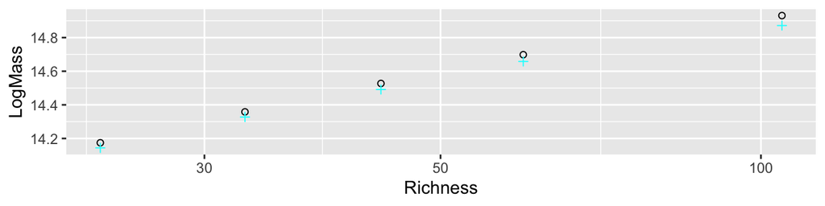

Absolute comparison of our implementation to the expected results for average masses. Note that over-plotting may obscure the expected values, if the approximated values are very close.

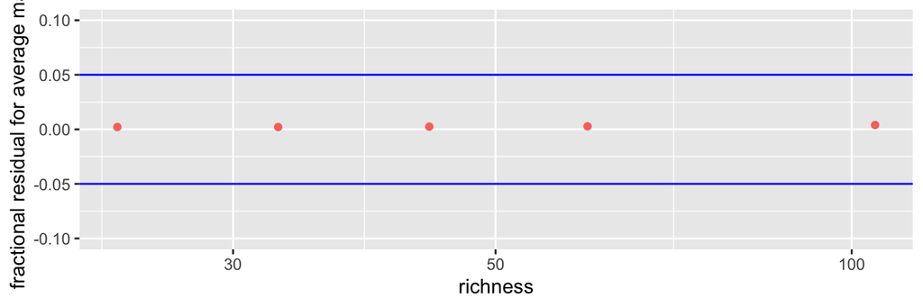

Relative residual implementation or our approximation to the expected results for average masses. Points in blue pass, and points in red fail, the absolute residual test.

## 3.6 Number Counts and Masses in DESY1

**This test requires running y1_analysis.ini in cosmosis_tests first**

In this section, we compare the stacked number counts and mass predictions in stacked richness/mass bins for a y1 like analysis. These values are the integrated results using components listed above. For this testing, we compare results from our implementation to the implementations from Matteo Costanzi for the y1 cosmology analysis (DES 2019). The test is conducted for the following set of cosmology and scaling relation parameters specified in **cosmosis_tests/values_comp_y1.in**

1. The comparisons are made at 4 unique values of $\lambda$ bins and 3 unique values of $z$ bins.
2. Over the **number of bins** tested and for the stacked **number counts**, the maximum magnitude of the absolute residual between the expected value and our calculated value is $5.236409$; the maximum magnitude of the fractional residual is $0.0027277$.
3. Over the **number of bins** tested and for the stacked **average masses**, the maximum magnitude of the absolute residual between the expected value and our calculated value is $9.67\times 10^{-4}$; the maximum magnitude of the fractional residual is $6.6952478\times 10^{-5}$.

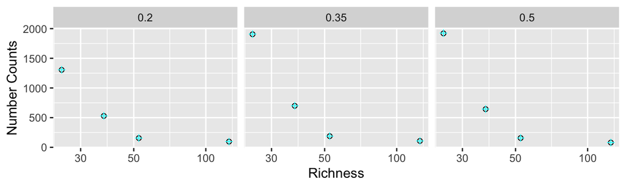

Absolute comparison of our implementation to the expected results. Note that over-plotting may obscure the expected values, if the approximated values are very close.

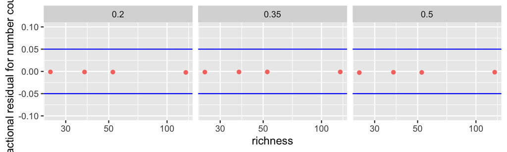

Relative residual implementation or our approximation to the expected results. Points in blue pass, and points in red fail, the absolute residual test.

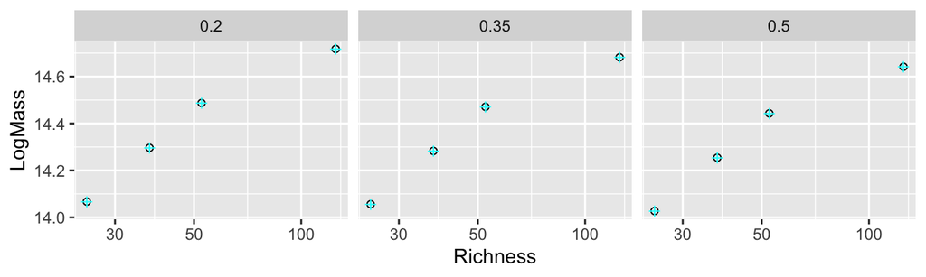

Absolute comparison of our implementation to the expected results for average masses. Note that over-plotting may obscure the expected values, if the approximated values are very close.

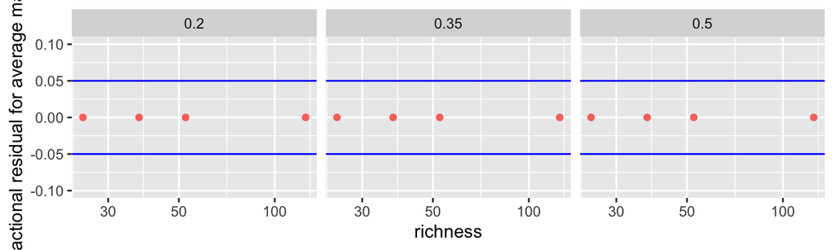

Relative residual implementation or our approximation to the expected results for average masses. Points in blue pass, and points in red fail, the absolute residual test.

## 3.7 Cluster Mass Profile

The Cluster Mass profiles are calculated by a **separate CosmoSIS module**, which is a python wrapper to Tom McClintock’s Cluster_toolkit code. The code exists in the folder `delta_sigma`.

**Before your run this test, make sure to go to the folder `deltasigma` and run `cosmosis deltasigma_test.ini` to produce the proper test files.** If you are using the supplied `GNUmakefile` to build the document, this is done automatically.

### 3.7.1 $\xi$ NFW

$\xi_{NFW}(r)$ is the cluster matter correlation function in the 1-halo regime, adopting an NFW model.

For this testing, we compare results from our implementation to the function evaluations from directly calling Tom McClintock’s python/c package, for a cluster of $M_{200m}=3.199267137797384375e+14 M_\odot/h$ and $c=5$.

1. The comparisons are made at 1000 unique values of $r$.
2. Over the range tested ($0.01 < r < 1000$), the maximum magnitude of the absolute residual between the expected value and our calculated value is $4.7036449\times 10^{4}$; the maximum magnitude of the fractional residual is $6.63304$.
3. For this test, we require the relative differences to be less than $0.001$, or the absolute difference to be less than $10^{-12}$.
4. **For this test, 297 of 1000 points pass.**

The values of $\xi$ cover a very wide range, so a logarithmic $y$-axis is needed. However, many points in the plot have $\xi = 0$. In order to allow the use of a logarithmic axis, these points are suppressed.

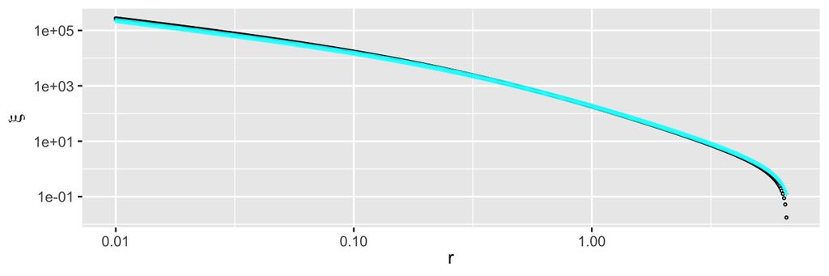

Absolute comparison of our implementation to the expected results. Note that over-plotting may obscure the expected values, if the approximated values are very close. Note that we suppress negative values of $\xi$ in this plot, so that we can use a log scale.

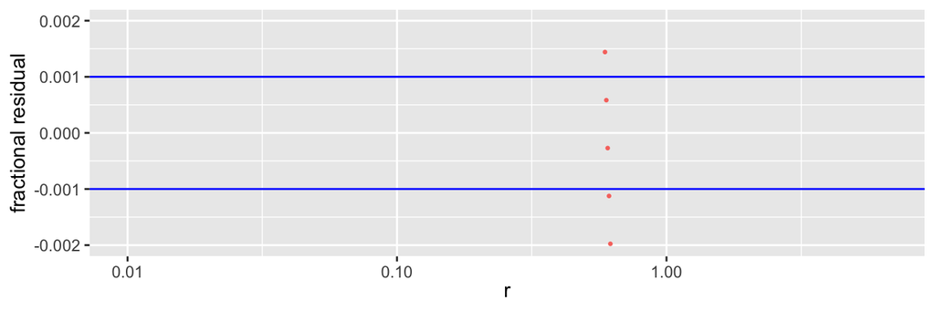

Relative residual implementation or our approximation to the expected results. Points in blue pass, and points in red fail, the absolute residual test.

### 3.7.2 $\xi$ 2-halo

$\xi_{mm}(r)$ is the matter correlation function in the cluster 2-halo regime, adopting a non-linear matter power spectrum, and not accounting for cluster bias.

For this testing, we compare results from our implementation to the function evaluations from directly calling Tom McClintock’s python/c package, for $z=0.201010$.

1. The comparisons are done at 819 unique values of $r$
2. Over the range tested ($0.01 < r < 124.192135$), the maximum magnitude of the absolute residual between the expected value and our calculated value is $13.0207564$; the maximum magnitude of the fractional residual is $0.005456$.
3. For this test, we require the relative differences to be less than $0.001$, or the absolute difference to be less than $10^{-12}$.
4. **For this test, 289 of 819 points pass.**

The values of $\xi$ cover a very wide range, so a logarithmic $y$-axis is needed. However, many points in the plot have $\xi = 0$. In order to allow the use of a logarithmic axis, these points are suppressed.

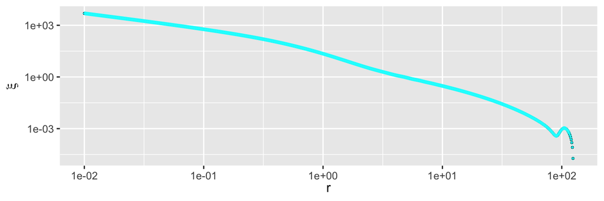

Absolute comparison of our implementation to the expected results. Note that over-plotting may obscure the expected values, if the approximated values are very close. Note that we suppress negative values of $\xi$ in this plot, so that we can use a log scale.

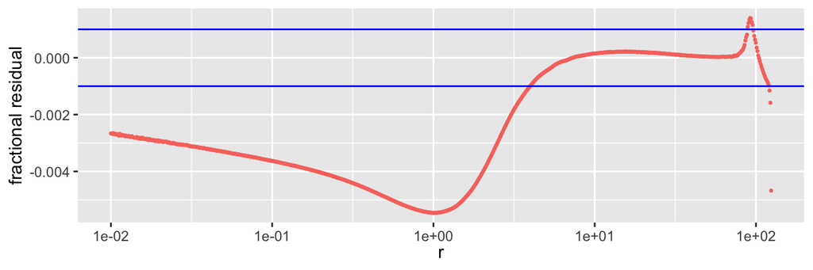

Relative residual comparison or our implementation to the expected results. Points in blue pass, and points in red fail, the absolute residual test. Note that points for which both the predicted and expected values are zero are suppressed.

### 3.7.3 $\Sigma$ NFW

$\Sigma_{NFW}(R)$ is the cluster surface mass density profile in the 1-halo regime, adopting an NFW model.

For this testing, we compare results from our implementation to the function evaluations from directly calling Tom McClintock’s python/c package, for a cluster of $M_{200m}=3.199267137797384375e+14 M_\odot/h$ and $c=5$.

1. The comparisons are done at 1000 unique values of $R$.
2. Over the range tested ($0.01 < R < 50.118723$), the maximum magnitude of the absolute residual between the expected value and our calculated value is $214.9037106$; the maximum magnitude of the fractional residual is $0.1395339$.
3. For this test, we require the relative differences to be less than $0.001$, or the absolute difference to be less than $10^{-12}$.
4. **For this test, 3 of 1000 points pass.**

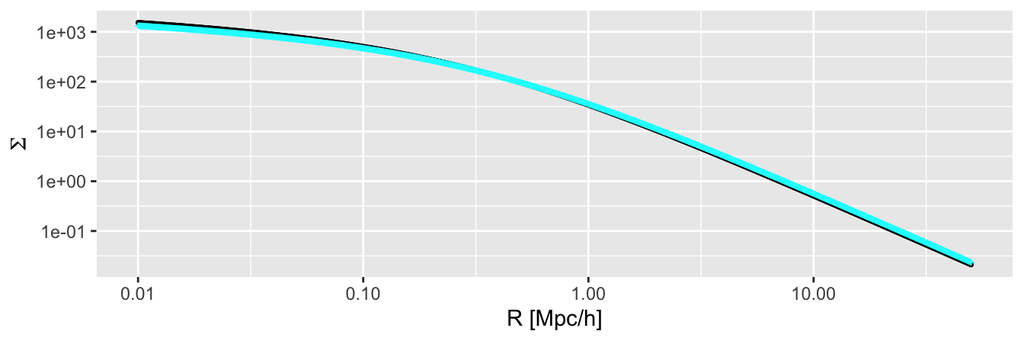

Absolute comparison of our implementation to the expected results. Note that over-plotting may obscure the expected values, if the approximated values are very close.

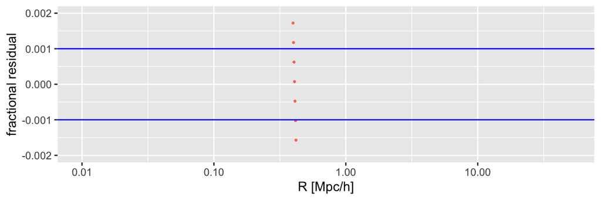

Relative residual comparison or our approximation to the expected results. Points in blue pass, and points in red fail, the absolute residual test.

### 3.7.4 $\Sigma$ 2-halo

$\Sigma_{mm}(R)$ is the cluster surface mass density profile in the cluster 2-halo regime, adopting a non-linear matter power spectrum, and not accounting for cluster bias.

1. The comparisons are done at 939 unique values of $R$.
2. Over the range tested ($0.01 < R < 29.790245$), the maximum magnitude of the absolute residual between the expected value and our calculated value is $0.1692425$; the maximum magnitude of the fractional residual is $0.0044657$.
3. For this test, we require the relative differences to be less than $0.01$, or the absolute difference to be less than $10^{-12}$.
4. **For this test, 939 of 939 points pass.**

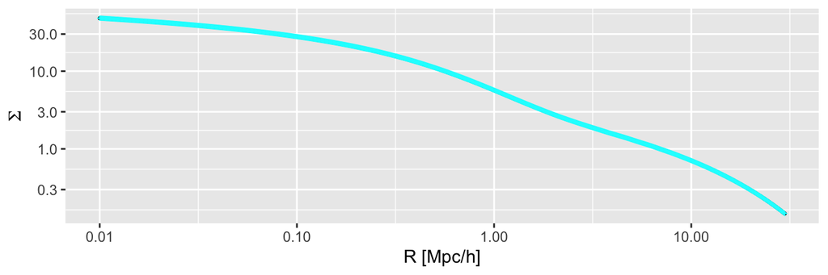

Absolute comparison of our implementation to the expected results. Note that over-plotting may obscure the expected values, if the approximated values are very close.

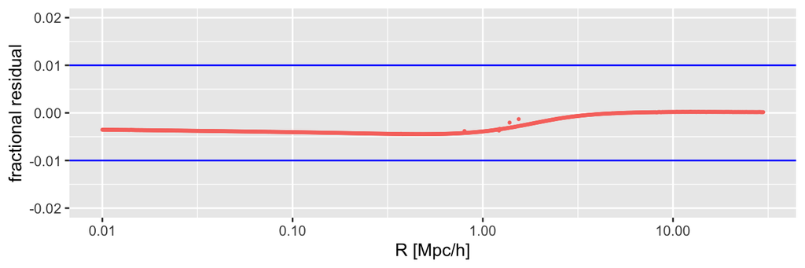

Relative residual comparison or our approximation to the expected results. Points in blue pass, and points in red fail, the absolute residual test.

### 3.7.5 Halo bias $b(M_{200m}, z)$

$b(M_{200m}, z)$ is the halo bias at mass $M_{200m}$ and redshift $z$.

For this testing, we compare results from our implementation to the function evaluations from directly calling Tom McClintock’s python/c package.

1. The comparisons are done at 2 different $z$ values, and 20 different $M_{200m}$ values.
2. Over the range tested ($12 < Log M_{200m} < 15.8$), the maximum magnitude of the absolute residual between the expected value and our calculated value is $0.0042618$; the maximum magnitude of the fractional residual is $2.199569\times 10^{-4}$.
3. For this test, we require the relative differences to be less than $0.001$, or the absolute difference to be less than $10^{-12}$.
4. **For this test, 40 of 40 points pass.**

Each panel in the figure below corresponds to a $z$ bin; the value of $z$ is specified in the panel top label.

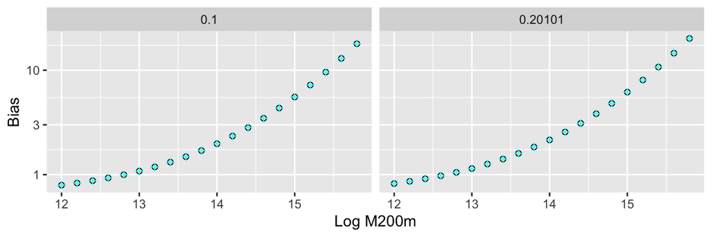

Absolute implementation of our approximation to the expected results. Note that over-plotting may obscure the expected values, if the approximated values are very close.

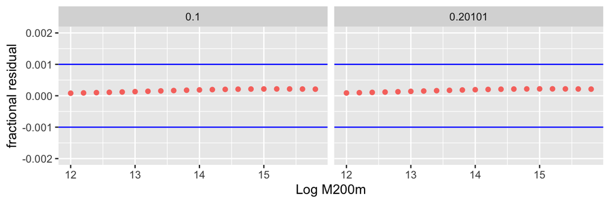

Relative residual implementation of our approximation to the expected results. Blue points pass, and red points fail, the absolute residual test.

## 3.8 Mass Profile corrections

### 3.8.1 Mis-centering offset

$P(R_{mis})$ is the probabilistic distribution of the mis-centering offset $R_{mis}$. Our calculation is implemented in the file `roffset_t.hh`.

For this testing, we compare our function output to the evaluations from Yuanyuan Zhang in the DES Y1 centering analysis (Zhang et al. 2019).

1. The comparisons are done at 20 unique $R_{mis}$ values.
2. Over the range tested $(0.01 < R_{mis} < 2)$, the maximum magnitude of the absolute residual between the expected value and our approximation is $8.8817842\times 10^{-16}$; the maximum magnitude of the fractional residual is $3.9331606\times 10^{-16}$.
3. For this test, we require the relative residuals to be less than $10^{-6}$, or the absolute residuals to be less than $10^{-12}$.
4. **For this test, 20 of 20 points pass.**

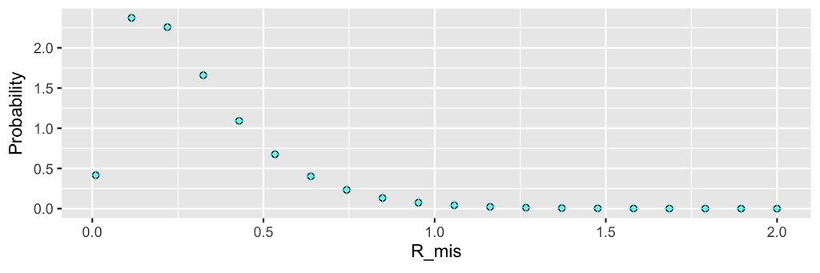

Absolute comparison of our implementation to the expected results. Note that over-plotting may obscure the expected values, if the approximated values are very close.

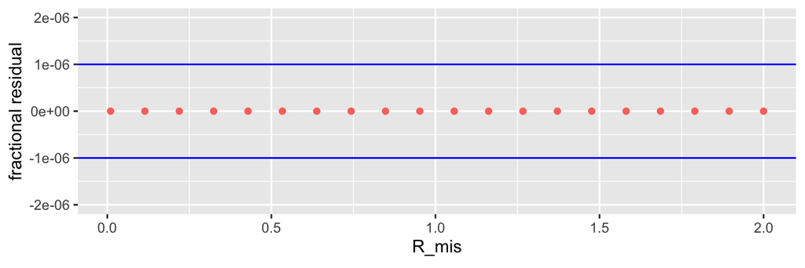

Relative residual comparison or our implementation to the expected results. Points in blue pass, and points in red fail, the absolute residual test.

## 3.9 Lensing

### 3.9.1 Critical density

$\Sigma_{crit}(z_l, z_s)$ is the inverse of the critical surface density of a lens system, which changes with the redshift of the lens $z_l$ and the redshift of the source galaxy $z_s$. Our calculation is implemented in the file `sigma_crit_inverse_t.hh`.

For this testing, we compare our function output to the evaluations using the astropy package with a flat cosmology $\Omega_m=0.3$, $\Omega_b=0.06$, $h_0=0.7$.

1. The comparisons are done at, 100 unique $z_s$ values, with 10 different $z_l$ values
2. Over the range tested ($0.01 < zs < 1$), the maximum magnitude of the absolute residual between the expected value and our calculated value is $4.7767481\times 10^{-17}$; the maximum magnitude of the fractional residual is $0.1347652$.
3. For this test, we require the relative differences to be less than $10^{-4}$, **or** the absolute difference to be less than $10^{-21}$.
4. **For this test, 460 of 1000 points pass.**

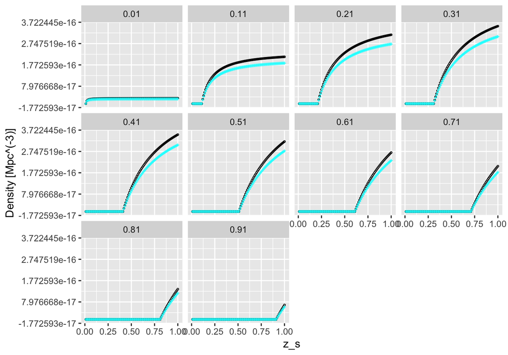

Absolute comparison of our implementation to the expected results. Note that over-plotting may obscure the expected values, if the approximated values are very close.

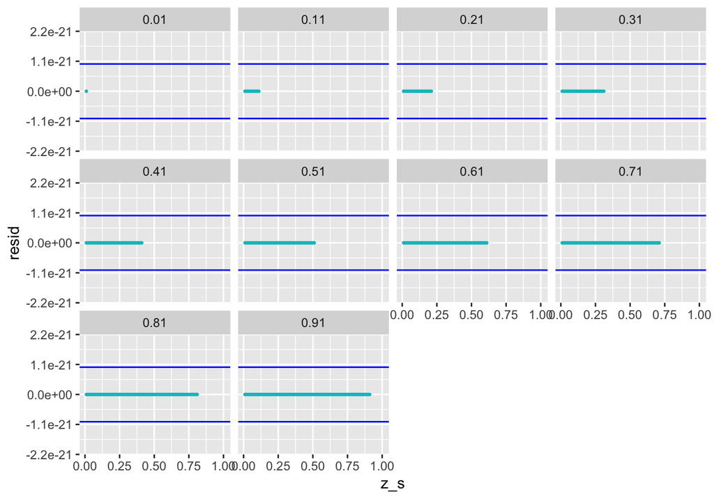

Absolute residual comparison of our implementation to the expected results. Blue points pass, and red points fail, the relative residual test.

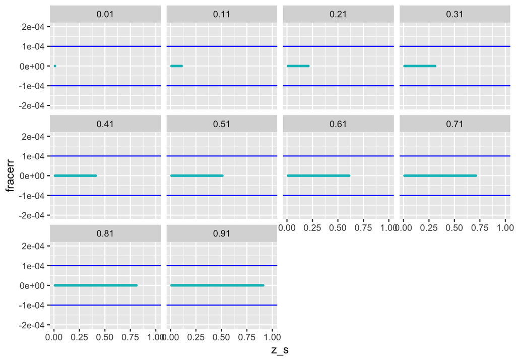

Relative residual comparison or our implementation to the expected results. Points in blue pass, and points in red fail, the absolute residual test. In this plot, the relative residual is forced to be 0 when both the true and test values are 0, as is the case when zs <= zl